# HW4

```python
# Increase the width of the notebook

from IPython.core.display import display, HTML
display(HTML("<style>.container { width:90% !important; }</style>"))
```

```python
# Import required libraries

import pandas as pd
import seaborn as sns
import matplotlib.pyplot as plt
import numpy as np

from sklearn.ensemble import RandomForestClassifier
from sklearn.svm import SVC
from sklearn.model_selection import GridSearchCV, RandomizedSearchCV, cross_val_score
from sklearn.metrics import accuracy_score

from scipy.spatial.distance import directed_hausdorff
```

```python
# To print variable names (For axes names)

def namestr(obj, namespace):
    return [name for name in namespace if namespace[name] is obj]
```

```python
musk_data = pd.read_csv("HW4-data/musk1.csv", header=None)
df = musk_data.copy()
columns = ["Bag class","Bag Id"]
for i in range(2,len(df.columns)):
    columns.append(f"Feature {i-1}")
df.columns = columns
df.head()
```

|  | Bag class | Bag Id | Feature 1 | Feature 2 | Feature 3 | Feature 4 | Feature 5 | Feature 6 | Feature 7 | Feature 8 | ... | Feature 157 | Feature 158 | Feature 159 | Feature 160 | Feature 161 | Feature 162 | Feature 163 | Feature 164 | Feature 165 | Feature 166 |
| --- | --- | --- | --- | --- | --- | --- | --- | --- | --- | --- | --- | --- | --- | --- | --- | --- | --- | --- | --- | --- | --- |
| 0 | 1 | 1 | 42 | -198 | -109 | -75 | -117 | 11 | 23 | -88 | ... | -238 | -74 | -129 | -120 | -38 | 30 | 48 | -37 | 6 | 30 |
| 1 | 1 | 1 | 42 | -191 | -142 | -65 | -117 | 55 | 49 | -170 | ... | -238 | -302 | 60 | -120 | -39 | 31 | 48 | -37 | 5 | 30 |
| 2 | 1 | 1 | 42 | -191 | -142 | -75 | -117 | 11 | 49 | -161 | ... | -238 | -73 | -127 | -120 | -38 | 30 | 48 | -37 | 5 | 31 |
| 3 | 1 | 1 | 42 | -198 | -110 | -65 | -117 | 55 | 23 | -95 | ... | -238 | -302 | 60 | -120 | -39 | 30 | 48 | -37 | 6 | 30 |
| 4 | 1 | 2 | 42 | -198 | -102 | -75 | -117 | 10 | 24 | -87 | ... | -238 | -73 | -127 | 51 | 128 | 144 | 43 | -30 | 14 | 26 |

5 rows × 168 columns

```python
# df["Bag Id"].nunique() # Number of bags=92
df.groupby("Bag Id")["Bag class"].agg("mean").value_counts() # 47 Musk, 45 Non-Musk
```

```
1.0    47
0.0    45
Name: Bag class, dtype: int64
```

```python
(df.iloc[:,2:]).duplicated().any() # All the rows are unique.
```

```
False
```

```python
features = df.iloc[:,2:].copy() # Features of the bag instances
features.head()
```

|  | Feature 1 | Feature 2 | Feature 3 | Feature 4 | Feature 5 | Feature 6 | Feature 7 | Feature 8 | Feature 9 | Feature 10 | ... | Feature 157 | Feature 158 | Feature 159 | Feature 160 | Feature 161 | Feature 162 | Feature 163 | Feature 164 | Feature 165 | Feature 166 |
| --- | --- | --- | --- | --- | --- | --- | --- | --- | --- | --- | --- | --- | --- | --- | --- | --- | --- | --- | --- | --- | --- |
| 0 | 42 | -198 | -109 | -75 | -117 | 11 | 23 | -88 | -28 | -27 | ... | -238 | -74 | -129 | -120 | -38 | 30 | 48 | -37 | 6 | 30 |
| 1 | 42 | -191 | -142 | -65 | -117 | 55 | 49 | -170 | -45 | 5 | ... | -238 | -302 | 60 | -120 | -39 | 31 | 48 | -37 | 5 | 30 |
| 2 | 42 | -191 | -142 | -75 | -117 | 11 | 49 | -161 | -45 | -28 | ... | -238 | -73 | -127 | -120 | -38 | 30 | 48 | -37 | 5 | 31 |
| 3 | 42 | -198 | -110 | -65 | -117 | 55 | 23 | -95 | -28 | 5 | ... | -238 | -302 | 60 | -120 | -39 | 30 | 48 | -37 | 6 | 30 |
| 4 | 42 | -198 | -102 | -75 | -117 | 10 | 24 | -87 | -28 | -28 | ... | -238 | -73 | -127 | 51 | 128 | 144 | 43 | -30 | 14 | 26 |

5 rows × 166 columns

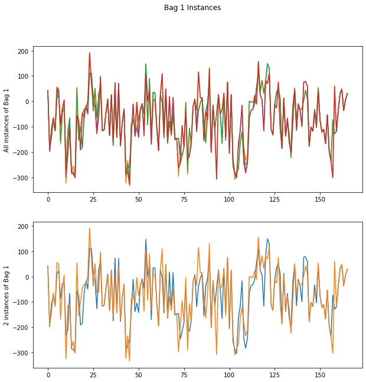

```python
# Line plots of Bag 1 instances (bag class = 1)

fig, (ax1, ax2) = plt.subplots(2,1, figsize=(10,10))
fig.suptitle('Bag 1 Instances')

# All the instances
sns.lineplot(x = range(0,len(features.columns)), y = features.iloc[0,:], ax=ax1)
sns.lineplot(x = range(0,len(features.columns)), y = features.iloc[1,:], ax=ax1)
sns.lineplot(x = range(0,len(features.columns)), y = features.iloc[2,:], ax=ax1)
sns.lineplot(x = range(0,len(features.columns)), y = features.iloc[3,:], ax=ax1)

ax1.set(ylabel='All instances of Bag 1')

# Just 2 instances
sns.lineplot(x = range(0,len(features.columns)), y = features.iloc[0,:], ax=ax2)
sns.lineplot(x = range(0,len(features.columns)), y = features.iloc[1,:], ax=ax2)

ax2.set(ylabel='2 instances of Bag 1');
```

```python
df[df['Bag class']==0][['Bag class','Bag Id']].head(5)
```

|  | Bag class | Bag Id |
| --- | --- | --- |
| 207 | 0 | 48 |
| 208 | 0 | 48 |
| 209 | 0 | 48 |
| 210 | 0 | 48 |
| 211 | 0 | 49 |

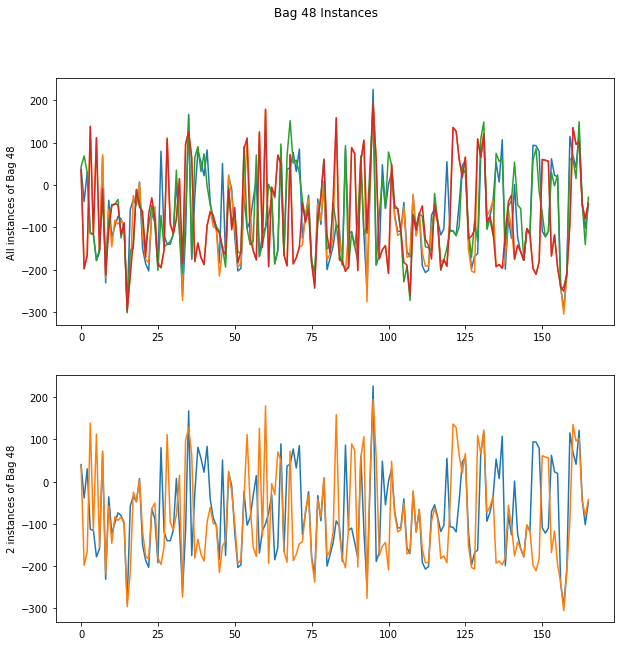

```python
# Line plots of Bag 48 instances (bag class = 0)

fig, (ax1, ax2) = plt.subplots(2,1, figsize=(10,10))
fig.suptitle('Bag 48 Instances')

# All the instances

sns.lineplot(x = range(0,len(features.columns)), y = features.iloc[207,:], ax=ax1)
sns.lineplot(x = range(0,len(features.columns)), y = features.iloc[208,:], ax=ax1)
sns.lineplot(x = range(0,len(features.columns)), y = features.iloc[209,:], ax=ax1)
sns.lineplot(x = range(0,len(features.columns)), y = features.iloc[210,:], ax=ax1);

ax1.set(ylabel='All instances of Bag 48')

# Just 2 instances

sns.lineplot(x = range(0,len(features.columns)), y = features.iloc[207,:], ax=ax2)
sns.lineplot(x = range(0,len(features.columns)), y = features.iloc[208,:], ax=ax2)

ax2.set(ylabel='2 instances of Bag 48');
```

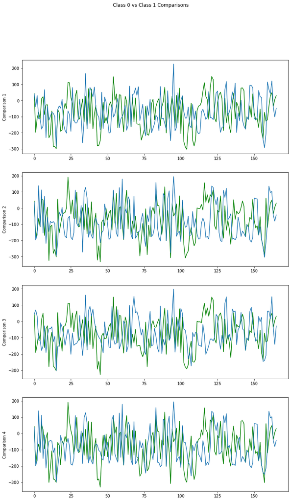

```python
# Line plot of a class 1 instance vs class 2 instance (Green lines for class 1)
# (Using different instances for each plot)

fig, (ax1, ax2, ax3, ax4) = plt.subplots(4,1, figsize=(12,20))
fig.suptitle('Class 0 vs Class 1 Comparisons')

axs = [ax1, ax2, ax3, ax4]

#
sns.lineplot(x = range(0,len(features.columns)), y = features.iloc[0,:], ax=ax1, color='g')
sns.lineplot(x = range(0,len(features.columns)), y = features.iloc[207,:], ax=ax1)

#
sns.lineplot(x = range(0,len(features.columns)), y = features.iloc[1,:], ax=ax2, color='g')
sns.lineplot(x = range(0,len(features.columns)), y = features.iloc[208,:], ax=ax2);

#
sns.lineplot(x = range(0,len(features.columns)), y = features.iloc[2,:], ax=ax3, color='g')
sns.lineplot(x = range(0,len(features.columns)), y = features.iloc[209,:], ax=ax3);

#
sns.lineplot(x = range(0,len(features.columns)), y = features.iloc[3,:], ax=ax4, color='g')
sns.lineplot(x = range(0,len(features.columns)), y = features.iloc[210,:], ax=ax4);

for ax in axs:
    ax.set(ylabel="Comparison "+namestr(ax, globals())[0][2])
```

### Looking at the plots, I can say that the some of the specific features have low values for Class 1 (Green Line), lower than the Class 0 counterpart of the same feature. Therefore, applying min transformation to the bag features might be useful and representative of the bag (for classifaction purpose). Also, with this representation, the aim is to define if some features are below a certain level or not, in order to classify the bag. Since values of some specific features are our concern, a tree-based algorithm would be a good fit for this scenario, giving these features very high importances. Also, I will try SVM Classifier, because it is stated as 'State of the Art Classifier' during the lecture.

# 1. MIN TRANSFORMATION

```python
min_transform_df_temp = df.copy()
```

```python
min_transform_df = min_transform_df_temp.groupby('Bag Id').apply(np.min)
min_transform_df.head()
```

| Bag Id | Bag class | Bag Id | Feature 1 | Feature 2 | Feature 3 | Feature 4 | Feature 5 | Feature 6 | Feature 7 | Feature 8 | ... | Feature 157 | Feature 158 | Feature 159 | Feature 160 | Feature 161 | Feature 162 | Feature 163 | Feature 164 | Feature 165 | Feature 166 |
| --- | --- | --- | --- | --- | --- | --- | --- | --- | --- | --- | --- | --- | --- | --- | --- | --- | --- | --- | --- | --- | --- |
| 1 | 1 | 1 | 42 | -198 | -142 | -75 | -117 | 11 | 23 | -170 | ... | -238 | -302 | -129 | -120 | -39 | 30 | 48 | -37 | 5 | 30 |
| 2 | 1 | 2 | 42 | -199 | -142 | -75 | -117 | 10 | 23 | -170 | ... | -238 | -300 | -127 | 51 | 124 | 143 | 42 | -31 | 14 | 25 |
| 3 | 1 | 3 | 40 | -173 | -142 | -74 | -117 | -7 | 5 | -171 | ... | -236 | -62 | -111 | -12 | 88 | 133 | 45 | -37 | -9 | -25 |
| 4 | 1 | 4 | 41 | -199 | -108 | -75 | -117 | -6 | 11 | -164 | ... | -241 | -298 | -132 | -120 | -41 | 30 | 47 | -40 | 2 | 27 |
| 5 | 1 | 5 | 41 | -192 | -143 | -74 | -117 | -8 | 5 | -173 | ... | -242 | -275 | -127 | -47 | -82 | 30 | 39 | -38 | -10 | -27 |

5 rows × 168 columns

```python
X = min_transform_df.iloc[:,2:]
y = min_transform_df['Bag class']
```

### Random Forest

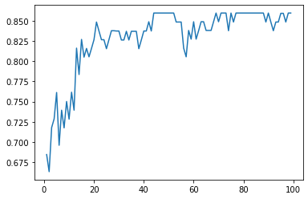

```python
scores = {}
n_trees = np.arange(1,100)
for i in n_trees:
    rf_base = RandomForestClassifier(random_state = 582, n_estimators=i)
    scores[i] = cross_val_score(rf_base, X, y, scoring='accuracy', cv=3).mean()

sns.lineplot(x= scores.keys(), y= scores.values());
```

```python
### After n=50, accuracy doesn't improve that much, therefore I will use values between 50 and 75, to be on the safe side.
```

```python
rf_base = RandomForestClassifier(random_state = 582)

param_grid = {'n_estimators': np.arange(50, 75),
             'max_features': np.arange(5, 20), # sqrt(166)~13, therefore try values around this.
             'max_depth': np.arange(5,100),
             'min_samples_leaf': np.arange(1,10)
             }

rf_cv = RandomizedSearchCV(rf_base, param_grid, n_iter=100, scoring='accuracy', cv=10, verbose=1, random_state=582)

rf_tuned = rf_cv.fit(X, y)
```

```
Fitting 10 folds for each of 100 candidates, totalling 1000 fits
```

```python
print(f"Best Score: {rf_tuned.best_score_:.4f}")
print("Best Set of Params of RF for Min Transform: ",rf_tuned.best_params_)
```

```
Best Score: 0.8689
Best Set of Params of RF for Min Transform:  {'n_estimators': 60, 'min_samples_leaf': 1, 'max_features': 13, 'max_depth': 59}
```

### SVM Classifier

```python
svc_base = SVC(random_state = 582)

param_grid_svc = {'C': [0.0001, 0.001, 0.01, 0.1, 1, 5, 10, 100],
             'kernel': ['linear','poly','rbf'],
             'degree': [5,6,7]}

svc_cv = GridSearchCV(svc_base, param_grid_svc, scoring='accuracy', cv=10, verbose=1)
svc_tuned = svc_cv.fit(X, y)
```

```
Fitting 10 folds for each of 72 candidates, totalling 720 fits
```

```python
print(f"Best Score: {svc_tuned.best_score_:.4f}")
print("Best Set of Params of SVC for Min Transform: ",svc_tuned.best_params_)
```

```
Best Score: 0.9000
Best Set of Params of SVC for Min Transform:  {'C': 5, 'degree': 6, 'kernel': 'poly'}
```

```python
# SVM was really fast and has a superior output than of the RF.
```

# 2. HAUSDORFF DISTANCE

```python
# https://arxiv.org/pdf/1309.5643.pdf

# In this paper, bag dissimarity representation methods are proposed for the MIL problems, and seems to give good results.
# Therefore, I will be trying one of the proposed dissimilarity approaches, namely 'Hausdorff Distance'.It makes sense that
# bags that are closer in terms of this distance will be more likely to belong to same class. The distance is defined as
# such: "Hausdorff Distance between two point sets is the largest of the distances between each possible pair (a,b), such
# that 'a' belongs to the first set and 'b' belongs to the second set.".
```

```python
new_df = df.copy()
new_df.head()
```

|  | Bag class | Bag Id | Feature 1 | Feature 2 | Feature 3 | Feature 4 | Feature 5 | Feature 6 | Feature 7 | Feature 8 | ... | Feature 157 | Feature 158 | Feature 159 | Feature 160 | Feature 161 | Feature 162 | Feature 163 | Feature 164 | Feature 165 | Feature 166 |
| --- | --- | --- | --- | --- | --- | --- | --- | --- | --- | --- | --- | --- | --- | --- | --- | --- | --- | --- | --- | --- | --- |
| 0 | 1 | 1 | 42 | -198 | -109 | -75 | -117 | 11 | 23 | -88 | ... | -238 | -74 | -129 | -120 | -38 | 30 | 48 | -37 | 6 | 30 |
| 1 | 1 | 1 | 42 | -191 | -142 | -65 | -117 | 55 | 49 | -170 | ... | -238 | -302 | 60 | -120 | -39 | 31 | 48 | -37 | 5 | 30 |
| 2 | 1 | 1 | 42 | -191 | -142 | -75 | -117 | 11 | 49 | -161 | ... | -238 | -73 | -127 | -120 | -38 | 30 | 48 | -37 | 5 | 31 |
| 3 | 1 | 1 | 42 | -198 | -110 | -65 | -117 | 55 | 23 | -95 | ... | -238 | -302 | 60 | -120 | -39 | 30 | 48 | -37 | 6 | 30 |
| 4 | 1 | 2 | 42 | -198 | -102 | -75 | -117 | 10 | 24 | -87 | ... | -238 | -73 | -127 | 51 | 128 | 144 | 43 | -30 | 14 | 26 |

5 rows × 168 columns

```python
# Pick the first bag from the dataset, that has class=1
a = new_df[new_df["Bag Id"]==1].iloc[:,2:].copy()

# Select the bags that belong to class1, and bags that belong to class 2.

class1_dict = {}
class2_dict = {}

for i in range(1,48):
    class1_dict[i] = new_df[new_df["Bag Id"]==i].iloc[:,2:].to_numpy()

for i in range(48,93):
    class2_dict[i] = new_df[new_df["Bag Id"]==i].iloc[:,2:].to_numpy()
```

```python
# Calculate the Hausdorff distances from the bag with id=1, to the other bags.

class1_len = []
for i in class1_dict.values():
    class1_len.append(directed_hausdorff(i, a)[0])

class2_len = []
for i in class2_dict.values():
    class2_len.append(directed_hausdorff(i, a)[0])
```

```python
np.mean(class1_len)
```

```
1347.71806408172
```

```python
np.mean(class2_len)
```

```
1631.7257444954403
```

```python
# It seems like bags that have the same class, in average, has a lower hausdorff distance to the bag1 . Therefore, they are
# more similar, (less dissimilar) to the bag1.
```

### Let's convert all the points to the Hausdorff distance.

```python
# Merge class1 and class2 point sets
z = {**class1_dict, **class2_dict}
```

```python
# Create the new feature matrix, a distance-matrix, by creating distance vectors for each bag (using Hausdorff distance of
# that bag to the other bags).

new_distances = {}
for i in range(1,93):
    distances = []
    for j in range(1,93):
        distances.append(directed_hausdorff(new_df[new_df["Bag Id"]==i].iloc[:,2:],
                                            new_df[new_df["Bag Id"]==j].iloc[:,2:])[0])
    new_distances[f"bag{i}"] = distances
```

```python
# Specify the Input and Target features

new_features = pd.DataFrame(new_distances).T
classes = df.groupby("Bag Id")["Bag class"].mean()
```

### SVM Classifier

```python
svc_base_2 = SVC(random_state = 582)

param_grid_svc_2 = {'C': [8, 9, 10],
             'kernel': ['poly', 'rbf'],
             'degree': [5],
             'gamma': ['scale', 'auto']}

svc_cv_2 = GridSearchCV(svc_base_2, param_grid_svc_2, scoring='accuracy', cv=10, verbose=1)
svc_tuned_2 = svc_cv_2.fit(new_features, classes)
```

```
Fitting 10 folds for each of 12 candidates, totalling 120 fits
```

```python
print(f"Best Score: {svc_tuned_2.best_score_:.4f}")
print("Best Params: ",svc_tuned_2.best_params_)
```

```
Best Score: 0.9233
Best Params:  {'C': 9, 'degree': 5, 'gamma': 'scale', 'kernel': 'rbf'}
```

```python
# As we can see, this bag representation is really good, compared to the previous one. I will use random forest, again, as
# my second model, just because I want to compare it with the previous RF model, that used MinTransform.
```

```python
rf_base_2 = RandomForestClassifier(random_state = 582)

param_grid_2 = {'n_estimators': np.arange(50, 75),
             'max_features': np.arange(5, 20), # sqrt(166)~13, therefore try values around this.
             'max_depth': np.arange(5,100),
             'min_samples_leaf': np.arange(1,10)
             }

rf_cv_2 = RandomizedSearchCV(rf_base_2, param_grid_2, n_iter=100, scoring='accuracy', cv=10, verbose=1, random_state=582)

rf_tuned_2 = rf_cv_2.fit(new_features, classes)
```

```
Fitting 10 folds for each of 100 candidates, totalling 1000 fits
```

```python
print(f"Best Score: {rf_tuned_2.best_score_:.4f}")
print("Best Params: ",rf_tuned_2.best_params_)
```

```
Best Score: 0.8711
Best Params:  {'n_estimators': 72, 'min_samples_leaf': 1, 'max_features': 13, 'max_depth': 70}
```

### Even though we saw a very good increase in the accuracy of SVM (2% increase at 90% is, indeed, really good), RF didn't improve that much. Increasing the grid space might result in a slight increase, but it is doubtful that it will. This work had an enlightening effect on me. I had no awareness of Support Vector Classifiers prior to this homework, and RF was my number one choice. Right now, I think that SVC is really powerful and fast. I will be, for sure, using more of it in the future.

```python
# This line is used to create html version of the notebook.
```

```python
import os

os.system('jupyter nbconvert --to html HW4.ipynb')
```

```
0
```